[deita](https://deita.eu/) [About](https://deita.eu/about.html)

# D4 · What Moves the Price

Capstone dossier · the variance decomposition, the context multipliers, and the standard dinner

Author

Dei M. Elurbe

Published

July 10, 2026

**Dossier, not the essay.** Backstage layer for technical readers; the capstone essay is the general-audience artifact. Corpus: **Snapshot · June 2026**, ~900 priced venues, roughly 4 in 10 of Amsterdam’s ~2,028 restaurants.

## The verdict

Take any dish price in Amsterdam and ask what put it there. The answer, decomposed over the 31,351 dishes at venues with scoreable menu text and a known borough (of the corpus’s 32,405): **what the dish is explains 59.5%** of the variation, **which venue sells it explains 16.8%**, and the remaining 23.7% is item-level noise within venues. The thesis of the whole project sits in that split: *what you pay is what you order, not where you sit.*

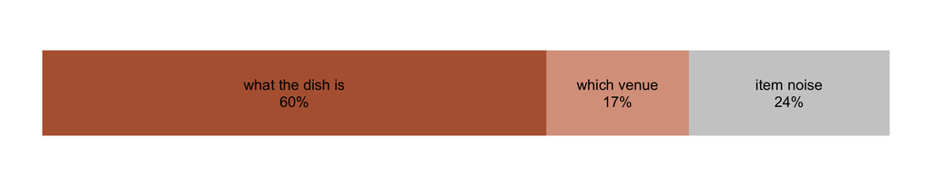

Figure 1: The variance decomposition: shares of log-price variation across the 31,351 decomposition dishes (venues with scoreable menu text and a known borough). The dish-type cell carries 59.5%; the venue, net of its dish mix, 16.8%.

```r
suppressPackageStartupMessages({library(dplyr); library(ggplot2)})

shares <- readr::read_csv("../../data/processed/dish_atlas_variance_shares.csv",
                          show_col_types = FALSE) |>
  mutate(source = factor(c("what the dish is", "which venue", "item noise"),
                         levels = rev(c("what the dish is", "which venue", "item noise"))))

ggplot(shares, aes(x = pct, y = "share", fill = source)) +
  geom_col(width = .55) +
  geom_text(aes(label = sprintf("%s\n%.0f%%", source, pct)),
            position = position_stack(vjust = .5), size = 3.2, lineheight = .95) +
  scale_fill_manual(values = c("item noise" = "grey80", "which venue" = "#d9a08a",
                               "what the dish is" = "#b5623f"), guide = "none") +
  theme_void()
```

## Why the obvious comparison lies

“Restaurant X is expensive” usually means “restaurant X’s average dish price is high”, and that number conflates two things: charging more for the same dishes, and *serving different dishes*. A steakhouse’s €28 average is mostly rib-eyes being rib-eyes. Separating those channels requires knowing what each dish is, which is what the coordinate system (dossier D1) provides. With every dish in a cell, one mixed-effects model splits the price into the three components above.

## Inside the venue’s 17%: mostly mist

Each venue’s price level (its random effect from the model above: how much pricier it is than its dish mix predicts) can be regressed on everything observable about it. The result is humbling: of that venue component, venue type plus menu styling (both text registers) explain roughly 5%, location roughly 3%, everything observable together about **8% of it, barely more than 1 point of the total 17**. The rest is venue idiosyncrasy: the specific ambition, rent, and pricing habits of one restaurant, invisible to any of our covariates.

This number has a structural consequence worth stating plainly, because it killed a product. A per-venue “deal or rip-off” verdict has at most 17 points of signal to work with, of which 93% is unexplained; any honest per-venue claim is therefore modest and caveat-heavy by construction. That is the deep reason the earlier per-venue Value Atlas was retired and this project prices dish-types instead.

## The ladder and the rungs: seeing this split inside the atlas

Read next to the going-rate atlas (D3), this dossier can look self-contradictory: the thesis says the dish decides, yet the atlas itself prices a carpaccio anywhere from €11.50 to €23. There is no contradiction; **the two dossiers display the same variance from two sides**, and the split is visible in the atlas table alone. Recompute it without any model: total log-price variance across the 32,405 dishes is 0.364; the average variance *within* a cell is 0.137. That is a 62/38 split between “which cell” and “everything else”, the crude version of the model’s 60/40 (the model partials out venue overlap properly). D3’s ranges *are* the 38%, displayed cell by cell.

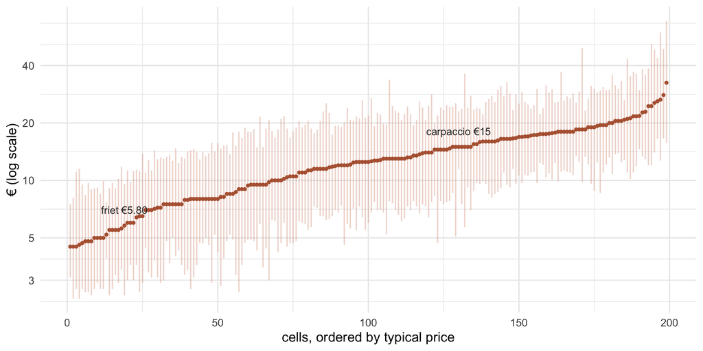

Figure 2: The ladder and the rungs: all 199 atlas cells ordered by typical price (dots), each with its 90% range (light bars), log scale. The ladder spans €4.50 to €32.50 (7×); a typical rung spans a factor ~2 to 3. Choosing the rung is most of the price; the rung’s own width is venue character and item noise, not geography.

```r
suppressPackageStartupMessages({library(dplyr); library(ggplot2)})
atlas <- readr::read_csv("../../data/processed/dish_atlas.csv", show_col_types = FALSE) |>
  arrange(typical_eur) |> mutate(rank = row_number())
marks <- atlas |> filter(cell %in% c("side · vegan · none · other",
                                     "starter · meat · raw · plate",
                                     "main · mixed · none · sharing")) |>
  mutate(mark = case_when(
    cell == "side · vegan · none · other"   ~ "friet €5.80",
    cell == "starter · meat · raw · plate"  ~ "carpaccio €15",
    TRUE                                    ~ "sharing board €35.50"))

ggplot(atlas, aes(rank, typical_eur)) +
  geom_linerange(aes(ymin = ppi_lo_eur, ymax = ppi_hi_eur),
                 colour = "#d9a08a", alpha = .4) +
  geom_point(colour = "#b5623f", size = .9) +
  geom_text(data = marks, aes(label = mark), vjust = -1.6, size = 3, colour = "grey20") +
  scale_y_log10(breaks = c(3, 5, 10, 20, 40)) +
  labs(x = "cells, ordered by typical price", y = "€ (log scale)") +
  theme_minimal()
```

**The walk a reader should take.** Predict the price of an unknown Amsterdam dish:

- *Knowing nothing*: the median dish is €13, and your 90% guessing band is **€4.00 to €27.50**, a 7× spread.
- *Told it is a carpaccio starter*: your guess is €15 and the band collapses to **€11.50 to €23**, a 2× spread. That collapse is the 60%. Nothing shrinks your uncertainty like knowing what the dish is.
- *Told additionally it is at a café, in Noord*: your guess drops to about €12, and the band shifts down with it, to roughly €9 to €18. But it barely *narrows*. Context moves the band; it does not tighten it.

**And the range is not geography.** The carpaccio band survives essentially intact inside every single borough:

```r
d  <- readr::read_csv("../../data/processed/dish_atlas_dishes.csv", show_col_types = FALSE)
ui <- readr::read_csv("../../data/processed/atlas_ui.csv", show_col_types = FALSE) |>
  select(osm_id, stadsdeel)
d |> filter(cell == "starter · meat · raw · plate") |> inner_join(ui, by = "osm_id") |>
  group_by(stadsdeel) |> filter(n() >= 15) |>
  summarise(dishes = n(),
            `5th pct` = sprintf("€%.2f", quantile(price_per_unit, .05)),
            median = sprintf("€%.2f", median(price_per_unit)),
            `95th pct` = sprintf("€%.2f", quantile(price_per_unit, .95))) |>
  knitr::kable()
```

Table 1: The carpaccio-starter cell within individual boroughs (those with at least 15 such dishes). The borough medians sit within about 5% of each other; the spread lives complete inside each one.

| stadsdeel | dishes | 5th pct | median | 95th pct |
| --- | --- | --- | --- | --- |
| Centrum | 68 | €12.18 | €15.50 | €20.44 |
| Oost | 22 | €13.76 | €15.00 | €25.00 |
| West | 26 | €11.75 | €14.72 | €21.73 |
| Zuid | 55 | €12.95 | €15.50 | €22.00 |

The arithmetic makes the thesis concrete. Moving the same €15 carpaccio to Noord saves about €1.60. Ordering the bife de chorizo instead costs about €10.50 more. And the reason location explains so little variance (3% of the venue component, well under 1% of the city-wide total) even though Noord reads −10.6%: the bulk of the city’s venues sit in boroughs within a few percent of Centrum (Zuid −1.4%, Oost −3.7%, West −5.1%), the double-digit discounts belong to boroughs holding few venues, and variance is measured on the squared ruler: a systematic shift of a few percent, squared against a 7× total spread, nearly vanishes.

What a rung’s width is actually made of: **venue character** (mostly invisible: ambition, portions, ingredient quality; D3 documents why some dish names bound this and others do not) and **item noise** (which carpaccio: the standard one or the Wagyu variant on the same menu). Neither is where you sit.

## The context multipliers

Adding the observable context as fixed effects (venue type, fanciness, area, with the cell and venue random effects retained) prices each modifier for *the same dish*:

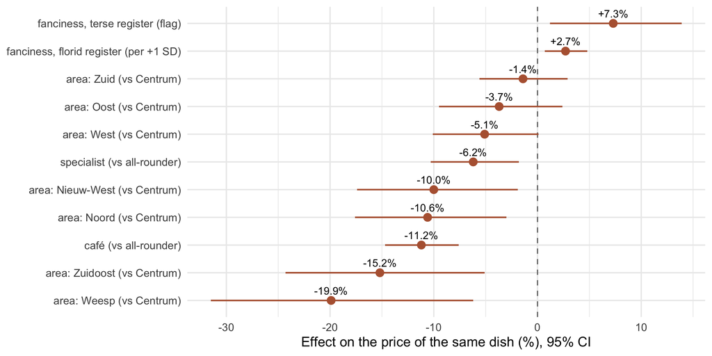

Figure 3: The context multipliers with 95% confidence intervals: what each factor adds to the price of the same dish. Reference categories: all-rounder venue, Centrum. Fanciness enters in its two text registers (Decision #42): florid wordiness per +1 SD (standard deviation), and the terse ingredient-list register as a flag.

```r
ctx <- readr::read_csv("../../data/processed/dish_atlas_context_effects.csv",
                       show_col_types = FALSE) |>
  mutate(label = case_when(
    block == "venue_type" ~ paste0("café / specialist: ", level),
    block == "fineness"   ~ "fanciness, florid register (per +1 SD)",
    block == "register"   ~ "fanciness, terse register (flag)",
    block == "area"       ~ paste0("area: ", level, " (vs Centrum)")),
    label = sub("café / specialist: cafe", "café (vs all-rounder)", label),
    label = sub("café / specialist: specialist", "specialist (vs all-rounder)", label))

ggplot(ctx, aes(x = pct, y = reorder(label, pct))) +
  geom_vline(xintercept = 0, linetype = "dashed", colour = "grey50") +
  geom_pointrange(aes(xmin = ci_lo, xmax = ci_hi), colour = "#b5623f", linewidth = .6) +
  geom_text(aes(label = sprintf("%+.1f%%", pct)), vjust = -0.8, size = 3) +
  labs(x = "Effect on the price of the same dish (%), 95% CI", y = NULL) +
  theme_minimal()
```

Worked arithmetic on one dish, using the atlas typical for a carpaccio starter (€15):

- the same carpaccio at a **café**: about €13.30;
- at a venue **1.5 SD wordier** than average: about €15.60;
- at a **terse-register** venue (the “word · word · word” menu): about €16.10;
- in **Noord**: about €13.40.

The multipliers are real, and they are small next to the choice *between* dishes: switching from the carpaccio to the bife de chorizo (€25.50) moves the bill more than any context multiplier in the city.

## Match the controls to the question

One dead-end from the build deserves its paragraph, because it is the methodological rule of this dossier. An early specification estimated the burger’s cuisine premium *net of its sandwich form* and produced burger +42%: an artifact, because sandwich-form is part of what a burger *is*, and controlling for it leaves only the weird residual burgers. The banked rule: **for a fair prediction, include all axes; for “what is X worth”, never control away the attributes that constitute X.** Every effect in this dossier follows it (the café effect does not control for “being a café’s kind of menu”; the fancy tax does not control for fancy dishes).

## The standard dinner: homogenisation, measured

If location markup were a real force, the most comparable dishes should show it most clearly. So build a **Standard Basket**: nine universal dish families every neighbourhood serves (soup, carpaccio/tartare, burrata, salad, burger, steak, fish of the day, pasta, tiramisu/cheesecake), keep venues carrying at least two of them, and fit one model where the basket-item effect absorbs *which* dishes and the area effect prices the location, apples-to-apples. Re-run on the audited canonical corpus for this dossier: 4,375 standard dishes across 528 venues.

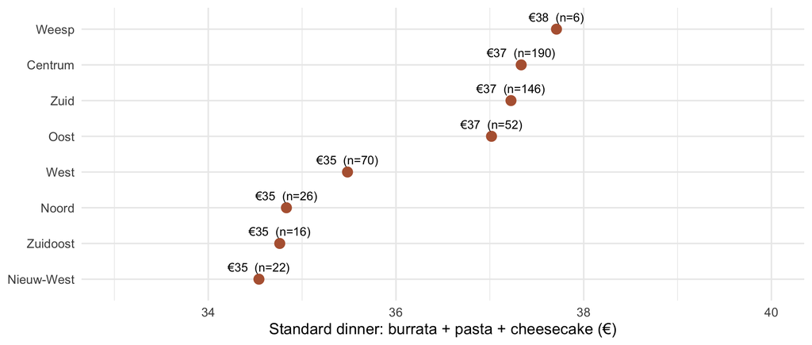

Figure 4: The standard dinner (burrata + pasta + cheesecake, model-predicted at average fanciness; the dessert term is the tiramisu/cheesecake family, one coefficient) by stadsdeel: €35 to €38 across the whole city, a 9% spread. No area’s basket-price level is statistically distinguishable from Centrum (all 95% CIs straddle zero; Weesp has 6 venues and is indicative only). The meatier carpaccio-steak-tiramisu bundle gives the same picture at €42 to €46; both are persisted in the data file.

```r
din <- readr::read_csv("_data/basket_dinner.csv", show_col_types = FALSE) |>
  filter(bundle == "burrata + pasta + cheesecake")

ggplot(din, aes(x = dinner, y = reorder(stadsdeel, dinner))) +
  geom_point(colour = "#b5623f", size = 3) +
  geom_text(aes(label = sprintf("€%.0f  (n=%d)", dinner, n_venues)),
            vjust = -0.9, size = 3) +
  scale_x_continuous(limits = c(33, 40)) +
  labs(x = "Standard dinner: burrata + pasta + cheesecake (€)", y = NULL) +
  theme_minimal()
```

Two honest readings, side by side. On the **full corpus** (every dish, every venue), the periphery discount is real and significant: Zuidoost −15.2%, Nieuw-West −10.0% against Centrum. On the **standard basket** (the universal classics, at the generalist venues that serve them), the point estimates run the same direction but small, and every area’s interval straddles zero. Both are true, and together they *are* the finding: the differences that exist live in the long tail of distinctive dishes and venues; for the everyman dinner, the city’s prices have converged. The earlier directional figure (€41 to €46 on the pre-audit corpus, carpaccio-steak-tiramisu bundle) survives the canonical re-run essentially unchanged (€42 to €46); the featured bundle switched to burrata-pasta-cheesecake (€35 to €38, same 9% spread) on 2026-07-02, an editorial choice, not a model change.

## Two cross-checks against the rest of the project

- **The tourist tax fits inside this picture.** D5’s +4.2% per SD of tourism exposure is a location effect, and location is ~3% of venue variation here; the two dossiers measure the same small-but-real channel with different instruments, and the area *ranking* (Centrum high, Zuidoost/periphery low) is near-identical across the M3 premium map and this model.
- **The café effect resolves an old wound.** M3’s strata had no café category (its “mortal wound” for per-venue claims); this decomposition finally prices café-ness directly, at −11%, with the dish held constant.

## The stress-test battery

[output not shown]

## What this is, and what it isn’t

- **Fanciness is proxied, in two registers.** Menu wordiness (“hand-dived Zeeland scallops, beurre blanc”) and the terse ingredient-list register (“krab · lavas · courgette”) both mark upscale positioning; neither is a Michelin scale. Their effects are small and should be read as directional.
- **Area effects are descriptive.** Stadsdeel enters as a label, not an explanation; the affluence interpretation of the centre-periphery gradient is deliberately deferred (Ethics §1) and is not claimed here.
- **Observational, not causal.** “A café charges −11% for the same dish” is a conditional description of this snapshot, not a lever anyone can pull.
- **The venue mist is honest ignorance.** The unexplained 93% of venue variation includes everything we cannot see: portions, quality, rent, ambition. It bounds what any per-venue product built on this corpus could ever claim.

*Erratum (21 July 2026), from the project’s number-trail audit (18 July 2026), three corrections. One: location’s explanatory share was stated on the wrong denominator (“3 of the 17”, “~3% of city-wide variation”); the ~3% is location’s share of the venue component, and of total variation it is well under 1%. The wording above now carries both denominators. Two: the decomposition’s input is now attributed precisely, 31,351 dishes of the corpus’s 32,405, not the full corpus. Three: the Standard Basket sample was misprinted as 4,384 dishes; the correct count is 4,375. The shares themselves and every price in this dossier were unaffected.*

## Lineage

- **Method + brief:** `docs/m5_typical_menus.md` (§4a layered effects, §4f the controls rule); audit record `docs/m5_data_audit_findings.md`.
- **Code:** `R/52_dish_atlas_context.R` (decomposition + two-register multipliers + fancy-tax table); `_prep/basket_rerun.R` (the canonical Standard Basket re-run); `_prep/terse_adoption_probes.R` (the register-adoption gate, record in D6).
- **Data:** `dish_atlas_variance_shares.csv`, `dish_atlas_context_effects.csv`, `_data/basket_area_index.csv`, `_data/basket_dinner.csv`.
- **Journal trail:** `2026-06-29_001` (the pivot: type+fineness vs location), `2026-06-30_001` (layered-effects design lock + the burger dead-end), `2026-06-30_004` (promotion), `2026-06-30_005/_006` (audit + fixes).
- **Sources:** restaurant websites (menus), OpenStreetMap (venue universe). All open data. **Snapshot · June 2026.**